# Hybridization in the Rocky Mountains

## Problem Statement:

Climate change is altering ecosystems worldwide, driving shifts in species distributions and in turn, increasing interactions between closely related species. One consequence of these changes is the potential for increased hybridization. This study investigates the role of a warming climate in influencing hybridization frequency between the American Marten (Martes Americana) and the Pacific Marten (Martes caurina) in the Rocky Mountains. I will analyze data collected to conclude if yearly temperatures, or other factors could have an impact of hybridization between the species using generalized linear models.

Climate data was taken from various weather stations using the Climate R package, and species data was collected from “https://www.researchgate.net/publication/381774135_Ecological_displacement_in_a_Rocky_Mountain_hybrid_zone_informs_management_of_North_American_martens_Martes#”

#### Here is a glimpse at the data used:

```r
glimpse(dat)
```

```
## Rows: 374
## Columns: 9
## $ X             <int> 1, 2, 3, 4, 5, 6, 7, 8, 9, 10, 11, 12, 13, 14, 15, 16, 1…
## $ number        <int> 195979, 195980, 214755, 214558, 214785, 214698, 214443, …
## $ year          <int> 2000, 2000, 2001, 2001, 2001, 2002, 2002, 2002, 2002, 20…
## $ sex           <chr> "female", "female", "female", "female", "female", "femal…
## $ consensus     <chr> "americana", "americana", "americana", "americana", "ame…
## $ lat           <int> NA, NA, NA, NA, NA, NA, NA, 48, 48, 48, NA, 47, NA, NA, …
## $ lon           <int> NA, NA, NA, NA, NA, NA, NA, -117, -117, -117, NA, -115, …
## $ ave_temp_year <dbl> 7.146836, 7.146836, 7.696832, 7.696832, 7.696832, 6.4069…
## $ hybrid_count  <int> 7, 7, 1, 1, 1, 5, 5, 5, 5, 5, 5, NA, 2, 2, 2, 2, 2, 2, 3…
```

## Rocky Mountain climate over the past decade:

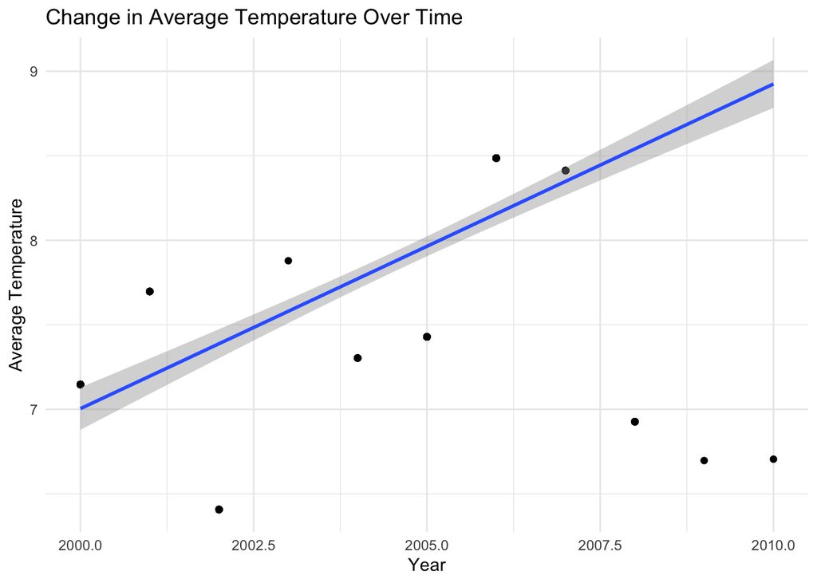

```r
ggplot( dat, aes(x = year, y = ave_temp_year))+
  geom_point() +
  geom_smooth(method = "lm", se = TRUE) +
  labs(x = "Year", y = "Average Temperature", title = "Change in Average Temperature Over Time") +
  theme_minimal()
```

### Statistical analysis of increased temperature by year:

The following model displays that average yearly temperature is significantly positively correlated with year. Meaning that as the year increases, so does average yearly temperature.

```r
 modt <- glm( formula = ave_temp_year ~ year, data  = dat)
 summary(modt)
```

```
##
## Call:
## glm(formula = ave_temp_year ~ year, data = dat)
##
## Coefficients:
##               Estimate Std. Error t value Pr(>|t|)
## (Intercept) -377.12912   24.47638  -15.41   <2e-16 ***
## year           0.19207    0.01221   15.73   <2e-16 ***
## ---
## Signif. codes:  0 '***' 0.001 '**' 0.01 '*' 0.05 '.' 0.1 ' ' 1
##
## (Dispersion parameter for gaussian family taken to be 0.3245951)
##
##     Null deviance: 199.77  on 369  degrees of freedom
## Residual deviance: 119.45  on 368  degrees of freedom
##   (4 observations deleted due to missingness)
## AIC: 637.69
##
## Number of Fisher Scoring iterations: 2
```

## Species Distributions:

The following density plot depicts longitudinal and latitudinal data of specimens collected from the years 2000 to 2010 within the Rocky Mountains:

```r
  rockymap <- get_stadiamap(bbox = c(left = -121.6,
           bottom = 44.5,
           right = -106.1,
           top = 51.4),
           maptype = "alidade_smooth",
          zoom = 7)
```

```
## ℹ © Stadia Maps © Stamen Design © OpenMapTiles © OpenStreetMap contributors.
```

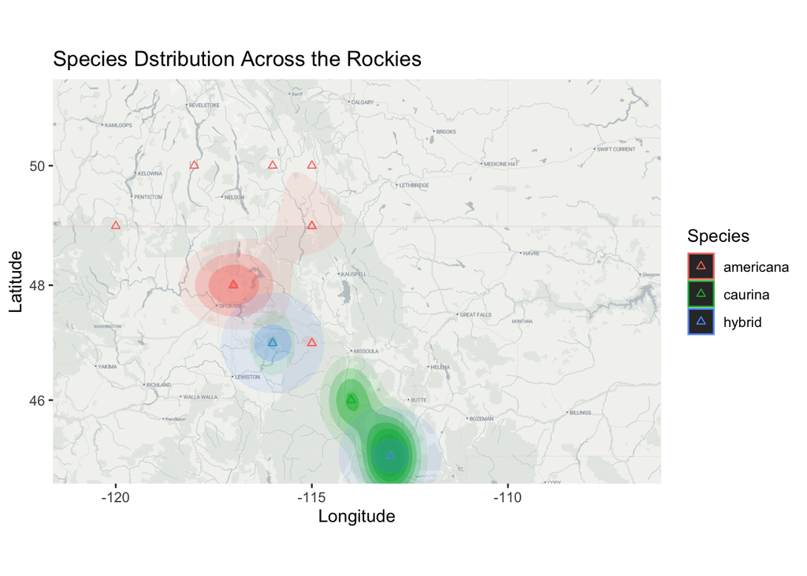

```r
ggmap(ggmap = rockymap)+
  stat_density2d(data = dat %>% filter(!is.na(consensus)),
                 aes(x = lon, y = lat, fill = consensus, alpha = ..level..),
                 geom = "polygon") +
    geom_point(data = dat %>% filter(!is.na(consensus)),
               aes(x = lon, y = lat, color = consensus),
               size = 1.5, shape = 2) +
  labs( x ="Longitude",y = "Latitude", color = "Species", title = "Species Dstribution Across the Rockies")+
  guides(fill = "none", alpha = "none")
```

### The following graph displays hybrid frequency in relation to year:

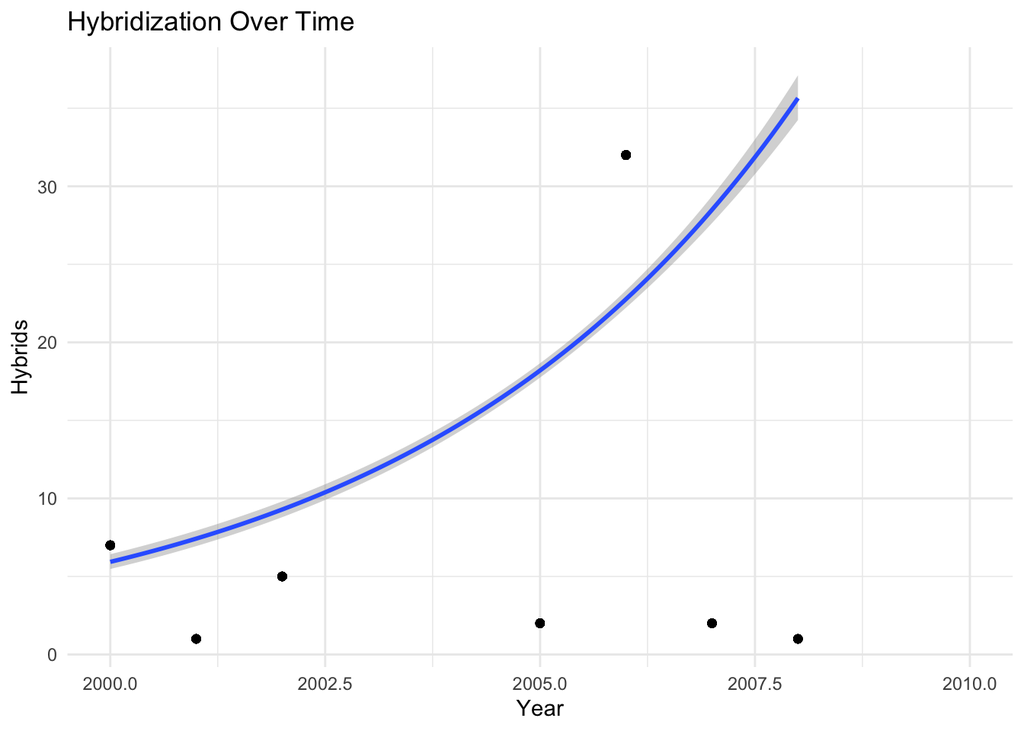

```r
ggplot( data = dat, mapping = aes(x = year, y = hybrid_count))+
  geom_point()+
  geom_smooth(method = "glm", method.args = list(family = poisson))+
  labs(x = "Year", y = "Hybrids", title = "Hybridization Over Time")+
  theme_minimal()
```

### The following graph displays hybrid frequency in relation to yearly average temperature:

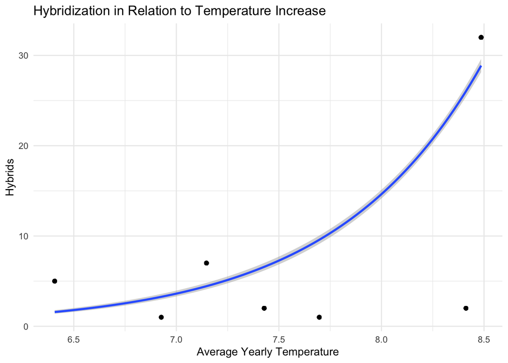

```r
ggplot( data = dat, mapping = aes(y = hybrid_count, x = ave_temp_year))+
  geom_point()+
  geom_smooth(method = "glm", method.args = list(family = poisson))+
  labs(x = "Average Yearly Temperature", y = "Hybrids", title = "Hybridization in Relation to Temperature Increase")+
  theme_minimal()
```

### Distribution modeling:

Below depicts the summary of model one, using average temperature and year to determine hybrid frequency: Anlysis of this data indicates that the average temperature variable has a statistically significant positive correlation with hybrid frequency.

```r
mod1 <- glm(hybrid_count ~ ave_temp_year + year,
    data = dat,
    family = poisson)
summary(mod1)
```

```
##
## Call:
## glm(formula = hybrid_count ~ ave_temp_year + year, family = poisson,
##     data = dat)
##
## Coefficients:
##                Estimate Std. Error z value Pr(>|z|)
## (Intercept)   168.31173   26.34363   6.389 1.67e-10 ***
## ave_temp_year   1.66943    0.05502  30.345  < 2e-16 ***
## year           -0.08929    0.01332  -6.704 2.02e-11 ***
## ---
## Signif. codes:  0 '***' 0.001 '**' 0.01 '*' 0.05 '.' 0.1 ' ' 1
##
## (Dispersion parameter for poisson family taken to be 1)
##
##     Null deviance: 4746.4  on 357  degrees of freedom
## Residual deviance: 1408.1  on 355  degrees of freedom
##   (16 observations deleted due to missingness)
## AIC: 2925.9
##
## Number of Fisher Scoring iterations: 5
```

```r
bestmod <- glm(data = dat, formula = step$formula)
summary(bestmod)
```

```
##
## Call:
## glm(formula = step$formula, data = dat)
##
## Coefficients: (1 not defined because of singularities)
##                           Estimate Std. Error    t value Pr(>|t|)
## (Intercept)              1.482e+04  5.340e-03  2.776e+06  < 2e-16 ***
## X                       -8.022e+00  1.870e-05 -4.291e+05  < 2e-16 ***
## number                  -5.760e-02  2.800e-08 -2.057e+06  < 2e-16 ***
## year                    -5.581e+00  1.168e-06 -4.780e+06  < 2e-16 ***
## sexmale                  3.840e-06  5.428e-04  7.000e-03    0.995
## sexunknown               1.085e+04  1.310e-03  8.284e+06  < 2e-16 ***
## consensuscaurina         2.134e+02  1.127e-04  1.893e+06  < 2e-16 ***
## consensushybrid         -1.634e+04  9.222e-03 -1.771e+06  < 2e-16 ***
## lat                      6.892e+01  3.055e-05  2.256e+06  < 2e-16 ***
## lon                      4.349e+01  3.268e-05  1.331e+06  < 2e-16 ***
## ave_temp_year           -2.909e+02  1.964e-04 -1.481e+06  < 2e-16 ***
## X:number                -9.634e-15  9.048e-13 -1.100e-02    0.992
## X:year                   1.032e-03  1.140e-08  9.051e+04 2.97e-15 ***
## X:sexmale               -2.455e-11  7.862e-11 -3.120e-01    0.775
## X:sexunknown             1.911e-01  6.220e-08  3.073e+06  < 2e-16 ***
## X:consensuscaurina      -2.513e-01  8.573e-08 -2.932e+06  < 2e-16 ***
## X:consensushybrid        4.407e+01  2.492e-05  1.769e+06  < 2e-16 ***
## X:lat                   -1.602e-01  8.104e-08 -1.976e+06  < 2e-16 ***
## X:lon                   -9.949e-02  5.733e-08 -1.735e+06  < 2e-16 ***
## X:ave_temp_year          3.129e-01  1.900e-07  1.647e+06  < 2e-16 ***
## number:year              2.129e-05  7.195e-12  2.959e+06  < 2e-16 ***
## number:sexmale           3.574e-13  3.689e-11  1.000e-02    0.993
## number:sexunknown        6.209e-04  1.669e-10  3.721e+06  < 2e-16 ***
## number:consensuscaurina -9.901e-04  5.584e-10 -1.773e+06  < 2e-16 ***
## number:consensushybrid          NA         NA         NA       NA
## number:lat              -2.971e-04  1.314e-10 -2.261e+06  < 2e-16 ***
## number:lon              -1.780e-04  1.350e-10 -1.318e+06  < 2e-16 ***
## number:ave_temp_year     1.314e-03  8.433e-10  1.558e+06  < 2e-16 ***
## year:sexmale            -1.945e-09  2.739e-07 -7.000e-03    0.995
## year:sexunknown         -5.496e+00  6.375e-07 -8.622e+06  < 2e-16 ***
## ---
## Signif. codes:  0 '***' 0.001 '**' 0.01 '*' 0.05 '.' 0.1 ' ' 1
##
## (Dispersion parameter for gaussian family taken to be 1.021633e-21)
##
##     Null deviance: 9.5522e+02  on 31  degrees of freedom
## Residual deviance: 3.0649e-21  on  3  degrees of freedom
##   (342 observations deleted due to missingness)
## AIC: -1471.6
##
## Number of Fisher Scoring iterations: 1
```

#### After comparing the models, it was determined that the model produced from stepAIC has higher performance when compared to model 1.

```r
compare_performance(mod1, bestmod)
```

```
## When comparing models, please note that probably not all models were fit
##   from same data.
```

```
## # Comparison of Model Performance Indices
##
## Name    | Model |   AIC (weights) | AICc (weights) |   BIC (weights)
## --------------------------------------------------------------------
## mod1    |   glm |  2925.9 (<.001) | 2926.0 (<.001) |  2937.6 (<.001)
## bestmod |   glm | -1471.6 (>.999) |  388.4 (>.999) | -1427.6 (>.999)
##
## Name    |      RMSE |     Sigma | Nagelkerke's R2 | Score_log | Score_spherical |    R2
## ---------------------------------------------------------------------------------------
## mod1    |     6.318 |     1.000 |           1.000 |    -4.078 |           0.039 |
## bestmod | 9.787e-12 | 3.196e-11 |                 |           |                 | 1.000
```

#### Below displays the various model assumptions:

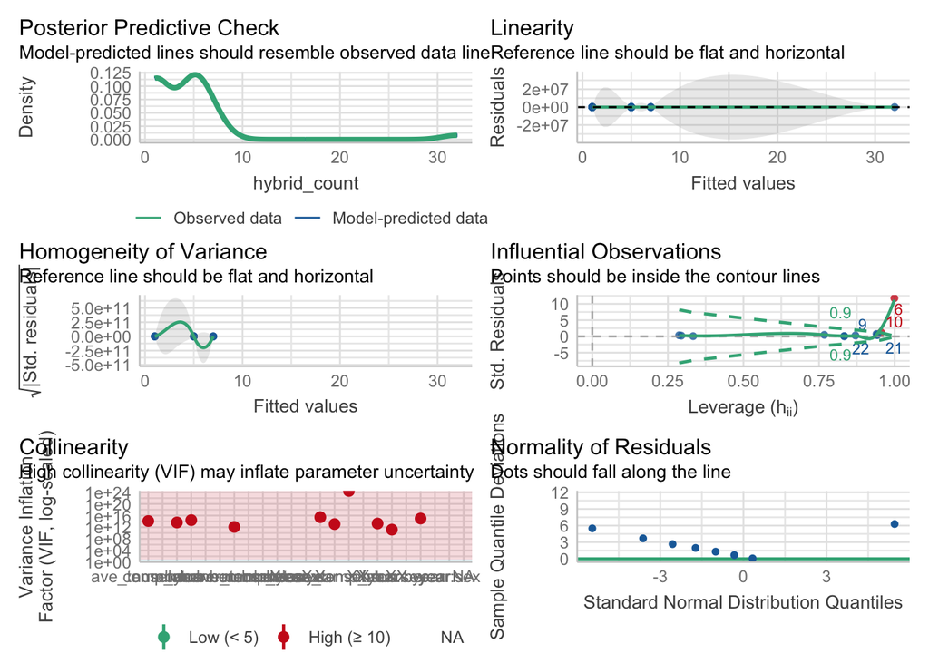

```r
check_model(bestmod)
```